# Part II - (Ford GoBike System Data)

## Dataset Overview

> This dataset includes information about individual rides made in a bike sharing system covering the greater San Francisco Bay Area. There are 183,412 data entries in the dataset with 16 columns(duration sec, start time, end time, start station id, start station name, start station latitude, start station longitude, end station id, end station name, end station latitude, end station longitude, bike id, user type, member birth year, member gender, and bike share for all trip.

## Is there a Relationship between Genders and Usertype?

Most Males were subscribers of the bike sharing Scheme.

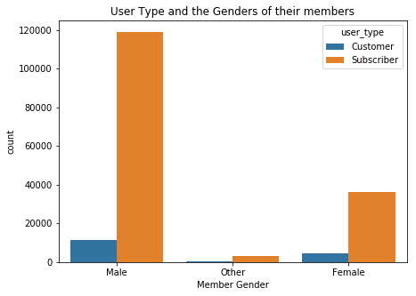

## Does the Age and User type affect the duration of their trips?

Majority of the people aged 20 to 50 were subscribers and customers, they also used the bike for longer duration in minutes than people of older ages

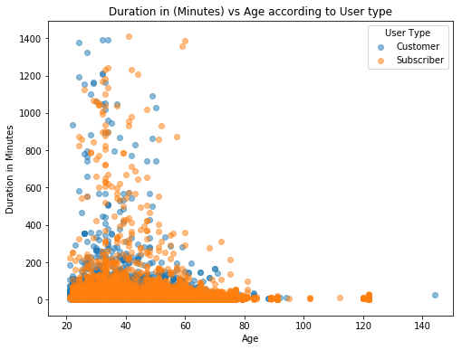

## Does the User type and Age have an effect on whether they used the bike for Alll Trips?

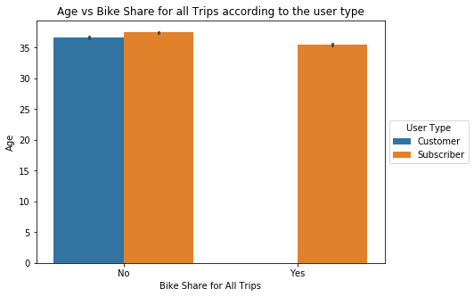